# Analysis of long term data

Analysis of the data sets using linear regression. See [this very nice post for an introduction with R](https://www.dataquest.io/blog/statistical-learning-for-predictive-modeling-r/).

Let’s first open the round 1 data.

Collection of data was started on 18 / 5 / 2017 0 ms at sensor 16:49 at mobile phone 15:53 at monitor time (+/- 2 minutes !)

Was stopped on 24 / 5 / 2017 516905067 ms at sensor 16:32 at mobile phone

```r
round1_raw <- read.csv(file="../../round1/data/AIRSENSE.CSV", header=TRUE, sep=" ", stringsAsFactors = FALSE)

start_TS <- as.POSIXct('2017-05-18 15:53:00')

round1_raw$timestamp <- start_TS + floor(round1_raw$timestamp / 1000)

# -1 are actually failures
round1_raw$humidity <- ifelse(round1_raw$humidity == -1, NA, round1_raw$humidity)
round1_raw$temperature <- ifelse(round1_raw$temperature == -1, NA, round1_raw$temperature)
names(round1_raw)[names(round1_raw) == "rawNO2_Mics"] <- "custom_MICS"

round1_ref <- read.csv(file="../../round1/data/reference.csv", header=TRUE, sep=",", stringsAsFactors = FALSE)
names(round1_ref)[names(round1_ref) == "TimeStamp"] <- "timestamp"
names(round1_ref)[names(round1_ref) == "NO2CNC1.AVG.PPB."] <- "NO2"
names(round1_ref)[names(round1_ref) == "NOXCNC1.AVG.PPB."] <- "NOX"
names(round1_ref)[names(round1_ref) == "NOCNC1.AVG.PPB."] <- "NO"

round1_ref$timestamp <- as.POSIXct(round1_ref$timestamp, format='%m/%d/%Y %H:%M:%S')

rm(start_TS)
```

Now we need to make the timestamps match

```r
first_useful_ts <- max(round1_raw$timestamp[1], round1_ref$timestamp[1])
last_useful_ts <- min(round1_raw$timestamp[nrow(round1_raw)], round1_ref$timestamp[nrow(round1_ref)])

# cut the data between these two

round1_raw <- round1_raw[which(round1_raw$timestamp <= last_useful_ts & round1_raw$timestamp >= first_useful_ts ), ]

round1_ref <- round1_ref[which(round1_ref$timestamp <= last_useful_ts & round1_ref$timestamp >= first_useful_ts ), ]

# now the let's match the two data sets, we'll interpolate the raw data to match the reference

interpolate <- function (raw, ref, colname) {
  ip <- approx(raw$timestamp,raw[[colname]], xout = ref$timestamp, rule = 2, method = "linear", ties = mean)
  temp <- data.frame(timestamp = ip$x, col = ip$y)
  names(temp)[names(temp) == 'col'] <- colname
  return(temp)
}

temp_raw <- data.frame()

for (name in names(round1_raw)) {
  if (name != 'timestamp') {
    if (nrow(temp_raw) == 0) {
      temp_raw = interpolate(round1_raw, round1_ref, name)
    } else {
      t = interpolate(round1_raw, round1_ref, name)
      temp_raw[[name]] = t[[name]]
    }
  }
}
round1_raw<- temp_raw

rm(t, temp_raw, name)
```

Instead of using all the samples, we can use 30 minutes averages:

```r
subsample <- function(data, interval) {
  temp = split(data, cut(strptime(data$timestamp, format="%F %R"), interval))

  subsampled = data.frame(timestamp = names(temp))
  for (name in names(data)) {
    if (name != 'timestamp') {
      avgs = sapply(temp, function(x)mean(x[[name]]))
      subsampled[[name]] = avgs
    }
  }
  subsampled
}

round1_raw_ss <- subsample(round1_raw, '30 mins')
round1_raw_ss$timestamp <- as.POSIXct(round1_raw_ss$timestamp)
round1_ref_ss <- subsample(round1_ref, '30 mins')
round1_ref_ss$timestamp <- as.POSIXct(round1_ref_ss$timestamp)
```

Let’s put all inside one dataframe:

```r
round1_ss <- round1_raw_ss
round1_ss$refNO2 = round1_ref_ss$NO2

#let's add the squared of each input
round1_ss$temperature_sq = round1_ss$temperature ^ 2
round1_ss$humidity_sq = round1_ss$humidity ^ 2
round1_ss$custom_MICS_sq = round1_ss$custom_MICS ^ 2

# we can delete the other data
rm(round1_raw_ss, round1_ref_ss)
```

Let’s do the linear regression using mics, temperature and humidity and their 2nd power too:

```r
round1_model1_thm <- lm(refNO2 ~
                          custom_MICS + custom_MICS_sq +
                          custom_MICS * temperature +
                          custom_MICS * temperature_sq +
                          custom_MICS * humidity +
                          custom_MICS * humidity_sq
                        , data=round1_ss)
summary(round1_model1_thm)
```

```
Call:
lm(formula = refNO2 ~ custom_MICS + custom_MICS_sq + custom_MICS *
    temperature + custom_MICS * temperature_sq + custom_MICS *
    humidity + custom_MICS * humidity_sq, data = round1_ss)

Residuals:
     Min       1Q   Median       3Q      Max
-20.8686  -2.7868  -0.3912   3.0796  18.0477

Coefficients:
                             Estimate Std. Error t value Pr(>|t|)
(Intercept)                 1.294e+01  1.791e+01   0.723 0.470450
custom_MICS                 3.507e-01  9.921e-02   3.535 0.000479 ***
custom_MICS_sq             -1.995e-04  2.996e-05  -6.659 1.49e-10 ***
temperature                 5.872e+00  1.665e+00   3.526 0.000493 ***
temperature_sq             -1.440e-01  4.086e-02  -3.525 0.000496 ***
humidity                   -2.107e+00  4.609e-01  -4.572 7.29e-06 ***
humidity_sq                 1.530e-02  3.351e-03   4.566 7.48e-06 ***
custom_MICS:temperature    -5.199e-02  9.979e-03  -5.210 3.70e-07 ***
custom_MICS:temperature_sq  1.141e-03  2.379e-04   4.794 2.67e-06 ***
custom_MICS:humidity        1.191e-02  2.712e-03   4.391 1.61e-05 ***
custom_MICS:humidity_sq    -9.568e-05  1.955e-05  -4.893 1.69e-06 ***
---
Signif. codes:  0 ‘***’ 0.001 ‘**’ 0.01 ‘*’ 0.05 ‘.’ 0.1 ‘ ’ 1

Residual standard error: 4.976 on 276 degrees of freedom
Multiple R-squared:  0.5529,    Adjusted R-squared:  0.5367
F-statistic: 34.13 on 10 and 276 DF,  p-value: < 2.2e-16
```

```r
compared_round1_m1 <- data.frame(timestamp = round1_ss$timestamp, reference = round1_ss$refNO2, fitted = fitted(round1_model1_thm))

print(paste('mean error', mean(compared_round1_m1$reference - compared_round1_m1$fitted), 'ppb'))
```

```
[1] "mean error -6.34594486908728e-17 ppb"
```

```r
print(paste('mean absolute error', mean(abs(compared_round1_m1$reference - compared_round1_m1$fitted)), 'ppb'))
```

```
[1] "mean absolute error 3.64663571657139 ppb"
```

Which will look like this:

```r
xrange <- range(compared_round1_m1$timestamp)
yrange <- range(compared_round1_m1$timestamp)

plot(compared_round1_m1$timestamp, compared_round1_m1$reference, type='l', xlab='time', ylab='ppb', col = 'red')
axis.POSIXct(1, at=seq(xrange[1], xrange[2], by="day"), format="%b %d")
```

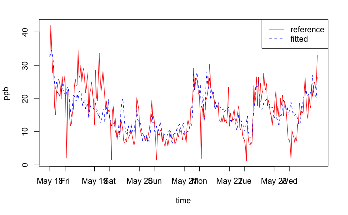

```r
lines(compared_round1_m1$timestamp, compared_round1_m1$fitted, type='l', lty = 2, col = 'blue')
legend("topright", legend = c("reference", "fitted"),
       text.width = strwidth("reference"),
       col=c('red', 'blue'),
       lty = 1:2, xjust = 1, yjust = 1)
```

```r
rm(xrange, yrange)
```

## Round 2

Now let’s basically repeat the same for round 2:

- Started: 10/01/2018 11:22:39 at mobile phone 11:23:21 at reference 0 at sensor

Let’s load and parse the data:

```r
round2_raw <- read.csv(file="../../round2/data/AIRSENSE.CSV", header=TRUE, sep=",", stringsAsFactors = FALSE)

start_TS <- as.POSIXct('2018-01-10 11:23:21')

round2_raw$timestamp <- start_TS + floor(round2_raw$timestamp / 1000)

# -1 are actually failures
round2_raw$humidity <- ifelse(round2_raw$humidity == -1, NA, round2_raw$humidity)
round2_raw$temperature <- ifelse(round2_raw$temperature == -1, NA, round2_raw$temperature)
# remove data that was not gathered
round2_raw <- round2_raw[ , -which(names(round2_raw) %in% c('ratio_NH3','ratio_CO','ratio_NO2', 'nh3', 'co', 'no2', 'c3h8', 'c4h10', 'ch4', 'h2', 'c2h5oh'))]

round2_ref <- read.csv(file="../../round2/data/reference.csv", header=TRUE, sep=",", stringsAsFactors = FALSE)
round2_ref$timestamp <- as.POSIXct(paste(round2_ref$Date, round2_ref$Time))
round2_ref <- round2_ref[ , -which(names(round2_ref) %in% c('Date','Time'))]
names(round2_ref)[names(round2_ref) == "NO2CNC1"] <- "NO2"
names(round2_ref)[names(round2_ref) == "NOXCNC1"] <- "NOX"
names(round2_ref)[names(round2_ref) == "NOCNC1"] <- "NO"

rm(start_TS)
```

Now we need to make the timestamps match

```r
first_useful_ts <- max(round2_raw$timestamp[1], round2_ref$timestamp[1])
last_useful_ts <- min(round2_raw$timestamp[nrow(round2_raw)], round2_ref$timestamp[nrow(round2_ref)])

round2_raw <- round2_raw[which(round2_raw$timestamp <= last_useful_ts & round2_raw$timestamp >= first_useful_ts ), ]
round2_ref <- round2_ref[which(round2_ref$timestamp <= last_useful_ts & round2_ref$timestamp >= first_useful_ts ), ]

temp_raw <- data.frame()

for (name in names(round2_raw)) {
  if (name != 'timestamp') {
    if (nrow(temp_raw) == 0) {
      temp_raw = interpolate(round2_raw, round2_ref, name)
    } else {
      t = interpolate(round2_raw, round2_ref, name)
      temp_raw[[name]] = t[[name]]
    }
  }
}
round2_raw<- temp_raw

rm(t, temp_raw, name)
```

Use 30 minutes averages:

```r
subsample <- function(data, interval) {
  temp = split(data, cut(strptime(data$timestamp, format="%F %R"), interval))

  subsampled = data.frame(timestamp = names(temp))
  for (name in names(data)) {
    if (name != 'timestamp') {
      avgs = sapply(temp, function(x)mean(x[[name]]))
      subsampled[[name]] = avgs
    }
  }
  subsampled
}

round2_raw_ss <- subsample(round2_raw, '30 mins')
round2_raw_ss$timestamp <- as.POSIXct(round2_raw_ss$timestamp)
round2_ref_ss <- subsample(round2_ref, '30 mins')
round2_ref_ss$timestamp <- as.POSIXct(round2_ref_ss$timestamp)
```

Here there are some “holes” in the data that will cause trouble later, we need to get rid of them:

```r
round2_raw_ss = round2_raw_ss[which(!is.na(round2_raw_ss$custom_MICS)), ]
round2_ref_ss = round2_ref_ss[which(!is.na(round2_raw_ss$custom_MICS)), ]
round2_raw_ss = round2_raw_ss[which(!is.na(round2_ref_ss$NO2)), ]
round2_ref_ss = round2_ref_ss[which(!is.na(round2_ref_ss$NO2)), ]
```

Let’s put everything into one data frame:

```r
round2_ss <- round2_raw_ss
round2_ss$refNO2 = round2_ref_ss$NO2

#let's add the squared of each input
round2_ss$temperature_sq = round2_ss$temperature ^ 2
round2_ss$humidity_sq = round2_ss$humidity ^ 2
round2_ss$custom_MICS_sq = round2_ss$custom_MICS ^ 2

# we can delete the other data
rm(round2_raw_ss, round2_ref_ss)
```

What happens if we use the model from round 1 on the data from round 2?

```r
compared_round2_m1 <- data.frame(timestamp = round2_ss$timestamp, reference = round2_ss$refNO2, fitted = predict(round1_model1_thm, round2_ss))

print(paste('mean error', mean(compared_round2_m1$reference - compared_round2_m1$fitted), 'ppb'))
```

```
[1] "mean error 6.95311127118879 ppb"
```

```r
print(paste('mean absolute error', mean(abs(compared_round2_m1$reference - compared_round2_m1$fitted)), 'ppb'))
```

```
[1] "mean absolute error 21.4990149073949 ppb"
```

```r
xrange <- range(compared_round2_m1$timestamp)
yrange <- range(compared_round2_m1$timestamp)

plot(compared_round2_m1$timestamp, compared_round2_m1$reference, type='l', xlab='time', ylab='ppb', col = 'red')
axis.POSIXct(1, at=seq(xrange[1], xrange[2], by="day"), format="%b %d")
```

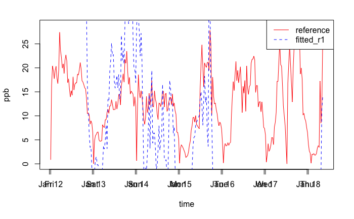

```r
lines(compared_round2_m1$timestamp, compared_round2_m1$fitted, type='l', lty = 2, col = 'blue')
legend("topright", legend = c("reference", "fitted_r1"),
       text.width = strwidth("reference"),
       col=c('red', 'blue'),
       lty = 1:2, xjust = 1, yjust = 1)
```

```r
rm(xrange, yrange)
```

Performances are total crap.

Now let’s create a model from round 2, we will create one with only temperature, humidity and mics:

```r
round2_model1_thm <- lm(refNO2 ~
                          custom_MICS + custom_MICS_sq +
                          custom_MICS * temperature +
                          custom_MICS * temperature_sq +
                          custom_MICS * humidity +
                          custom_MICS * humidity_sq
                        , data=round2_ss)
summary(round2_model1_thm)
```

```
Call:
lm(formula = refNO2 ~ custom_MICS + custom_MICS_sq + custom_MICS *
    temperature + custom_MICS * temperature_sq + custom_MICS *
    humidity + custom_MICS * humidity_sq, data = round2_ss)

Residuals:
     Min       1Q   Median       3Q      Max
-16.0259  -3.1815  -0.9543   2.8737  16.4611

Coefficients:
                             Estimate Std. Error t value Pr(>|t|)
(Intercept)                 4.212e+01  3.989e+01   1.056 0.291933
custom_MICS                 3.744e-01  6.639e-01   0.564 0.573241
custom_MICS_sq             -2.827e-04  7.211e-05  -3.920 0.000111 ***
temperature                 4.689e+00  1.274e+00   3.681 0.000278 ***
temperature_sq             -4.169e-01  9.504e-02  -4.387 1.61e-05 ***
humidity                   -9.267e-01  1.078e+00  -0.860 0.390562
humidity_sq                 3.806e-03  7.374e-03   0.516 0.606113
custom_MICS:temperature    -1.472e-01  3.386e-02  -4.347 1.91e-05 ***
custom_MICS:temperature_sq  1.015e-02  2.133e-03   4.760 3.06e-06 ***
custom_MICS:humidity        2.829e-03  1.822e-02   0.155 0.876716
custom_MICS:humidity_sq     9.499e-06  1.218e-04   0.078 0.937908
---
Signif. codes:  0 ‘***’ 0.001 ‘**’ 0.01 ‘*’ 0.05 ‘.’ 0.1 ‘ ’ 1

Residual standard error: 5.152 on 288 degrees of freedom
Multiple R-squared:  0.4094,    Adjusted R-squared:  0.3889
F-statistic: 19.96 on 10 and 288 DF,  p-value: < 2.2e-16
```

```r
compared_round2_m1 <- data.frame(timestamp = round2_ss$timestamp, reference = round2_ss$refNO2, fitted = fitted(round2_model1_thm))

print(paste('mean error', mean(compared_round2_m1$reference - compared_round2_m1$fitted), 'ppb'))
```

```
[1] "mean error 5.32919815671738e-17 ppb"
```

```r
print(paste('mean absolute error', mean(abs(compared_round2_m1$reference - compared_round2_m1$fitted)), 'ppb'))
```

```
[1] "mean absolute error 3.92942985719594 ppb"
```

```r
xrange <- range(compared_round2_m1$timestamp)
yrange <- range(compared_round2_m1$timestamp)

plot(compared_round2_m1$timestamp, compared_round2_m1$reference, type='l', xlab='time', ylab='ppb', col = 'red')
axis.POSIXct(1, at=seq(xrange[1], xrange[2], by="day"), format="%b %d")
```

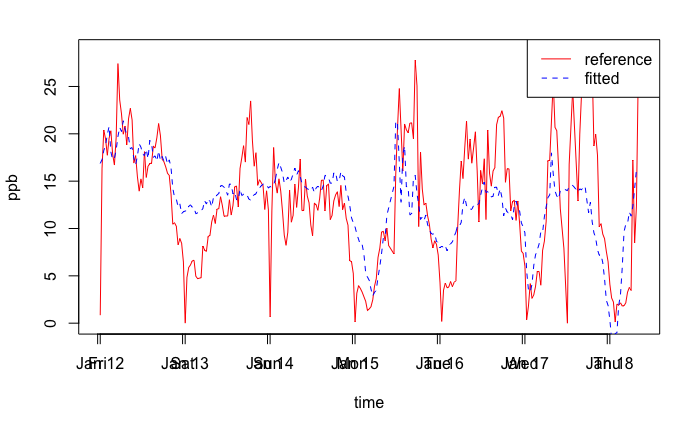

```r
lines(compared_round2_m1$timestamp, compared_round2_m1$fitted, type='l', lty = 2, col = 'blue')
legend("topright", legend = c("reference", "fitted"),
       text.width = strwidth("reference"),
       col=c('red', 'blue'),
       lty = 1:2, xjust = 1, yjust = 1)
```

```r
rm(xrange, yrange)
```

It works, but it’s not great. Now let’s also add pressure and the alphasense sensor diff:

```r
round2_model2_thmpa <- lm(refNO2 ~
                          custom_MICS + custom_MICS_sq +
                          custom_MICS * temperature +
                          custom_MICS * temperature_sq +
                          custom_MICS * humidity +
                          custom_MICS * humidity_sq +
                          custom_MICS * pressure +
                          custom_MICS * pressure_sq +
                          custom_MICS * alphadiff +
                          custom_MICS * alphadiff_sq
                        , data=round2_ss)
summary(round2_model2_thmpa)
```

```
Call:
lm(formula = refNO2 ~ custom_MICS + custom_MICS_sq + custom_MICS *
    temperature + custom_MICS * temperature_sq + custom_MICS *
    humidity + custom_MICS * humidity_sq + custom_MICS * pressure +
    custom_MICS * pressure_sq + custom_MICS * alphadiff + custom_MICS *
    alphadiff_sq, data = round2_ss)

Residuals:
     Min       1Q   Median       3Q      Max
-15.4348  -2.3372  -0.1448   2.0938  13.1638

Coefficients:
                             Estimate Std. Error t value Pr(>|t|)
(Intercept)                -1.361e+04  2.312e+04  -0.589 0.556466
custom_MICS                -2.380e+02  3.989e+02  -0.597 0.551207
custom_MICS_sq             -8.551e-04  1.491e-04  -5.736 2.51e-08 ***
temperature                 4.638e+00  1.129e+00   4.109 5.23e-05 ***
temperature_sq             -4.465e-01  8.911e-02  -5.011 9.61e-07 ***
humidity                    1.143e+00  9.552e-01   1.196 0.232546
humidity_sq                -1.015e-02  6.539e-03  -1.552 0.121836
pressure                    7.293e-01  1.898e-01   3.843 0.000151 ***
pressure_sq                -3.666e-06  9.494e-07  -3.861 0.000140 ***
alphadiff                  -1.172e-01  1.238e-01  -0.947 0.344445
alphadiff_sq                1.513e-07  1.582e-07   0.957 0.339638
custom_MICS:temperature    -6.959e-02  3.128e-02  -2.225 0.026884 *
custom_MICS:temperature_sq  4.999e-03  2.000e-03   2.499 0.013022 *
custom_MICS:humidity       -2.847e-02  1.600e-02  -1.779 0.076319 .
custom_MICS:humidity_sq     2.035e-04  1.068e-04   1.905 0.057791 .
custom_MICS:pressure       -7.645e-03  2.617e-03  -2.921 0.003778 **
custom_MICS:pressure_sq     3.820e-08  1.307e-08   2.924 0.003743 **
custom_MICS:alphadiff       3.188e-03  1.962e-03   1.625 0.105357
custom_MICS:alphadiff_sq   -4.085e-09  2.512e-09  -1.626 0.104998
---
Signif. codes:  0 ‘***’ 0.001 ‘**’ 0.01 ‘*’ 0.05 ‘.’ 0.1 ‘ ’ 1

Residual standard error: 4.308 on 280 degrees of freedom
Multiple R-squared:  0.5986,    Adjusted R-squared:  0.5728
F-statistic:  23.2 on 18 and 280 DF,  p-value: < 2.2e-16
```

```r
compared_round2_m2 <- data.frame(timestamp = round2_ss$timestamp, reference = round2_ss$refNO2, fitted = fitted(round2_model2_thmpa))

print(paste('mean error', mean(compared_round2_m2$reference - compared_round2_m2$fitted), 'ppb'))
```

```
[1] "mean error 3.36954805612761e-16 ppb"
```

```r
print(paste('mean absolute error', mean(abs(compared_round2_m2$reference - compared_round2_m2$fitted)), 'ppb'))
```

```
[1] "mean absolute error 3.06457682793224 ppb"
```

```r
xrange <- range(compared_round2_m2$timestamp)
yrange <- range(compared_round2_m2$timestamp)

plot(compared_round2_m2$timestamp, compared_round2_m2$reference, type='l', xlab='time', ylab='ppb', col = 'red')
axis.POSIXct(1, at=seq(xrange[1], xrange[2], by="day"), format="%b %d")
```

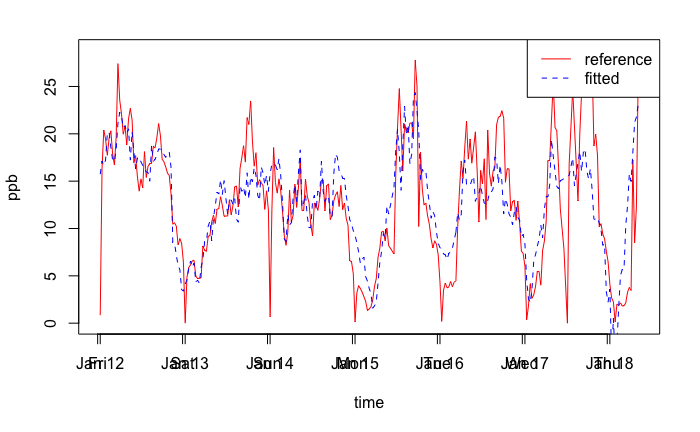

```r
lines(compared_round2_m2$timestamp, compared_round2_m2$fitted, type='l', lty = 2, col = 'blue')
legend("topright", legend = c("reference", "fitted"),
       text.width = strwidth("reference"),
       col=c('red', 'blue'),
       lty = 1:2, xjust = 1, yjust = 1)
```

```r
rm(xrange, yrange)
```

This looks much, much better. Compared to what I did with the JS example, where I used all variables up to the 3rd power, though, this is not that great.

## Round 3

cjmcu_red = ADCavg(CJMCU_4541_PINRED); cjmcu_ox = ADCavg(CJMCU_4541_PINOX);

Here the data sets are a bit different, let’s load them:

Started on 2/01/2019 at 13:45:48 Time at the monitoring station: 13:47:29

```r
round3_raw <- read.csv(file="../data/airsense.csv", header=TRUE, sep=",", stringsAsFactors = FALSE)
```

Reference data is split among different files:

```r
round3_ref = read.table("../data/reference_2019-01-04_2019-01-17.xlsx", header = TRUE)
```